# Human Acitivity Recognition

Manav Sehgal

1/31/2018

# Executive Summary

This data contains data from accelerometers on the belt, forearm, arm, and dumbell of 6 participants. Mostly for each sensor it contains the angle, avg, standard deviation, variance, kurtosis, skewness, amplitude, min and max for each of the rotation angles - pitch, roll, yaw. In addition is also contains the gyro, accel and magnetometer reading in each direction.

We tried 3 different models for prediction -** 1) Decision Tree, Random Forest without PCA, 3) Random Forest with PCA.**

# Analysis Overview

Devices such as Jawbone Up, Nike FuelBand, and Fitbit it is now possible to collect a large amount of data about personal activity relatively inexpensively.In this project, the goal is to use data from accelerometers on the belt, forearm, arm, and dumbell of 6 participants to identify if the barbell lifts were done correctly or incorrectly.

Training Data: https://d396qusza40orc.cloudfront.net/predmachlearn/pml-training.csv

Test Data: https://d396qusza40orc.cloudfront.net/predmachlearn/pml-testing.csv

# Exploratory Data Analysis

In this step we will load the data and do some exploratory analysis to see for relationships between the data and possible predictors.

### Load Data

```r
library(caret)
```

```r
library(stats)
library(ggplot2)
set.seed(1)
```

```r
file_url_training<-"https://d396qusza40orc.cloudfront.net/predmachlearn/pml-training.csv"
file_url_testing<-"https://d396qusza40orc.cloudfront.net/predmachlearn/pml-testing.csv"

#Dowload the files
training_file_name<-"pml-training.csv"

testing_file_name<-"pml-testing.csv"
if(!file.exists(training_file_name)){
download.file(file_url_training,training_file_name,method="curl")
}
if(!file.exists(testing_file_name)){
download.file(file_url_testing,testing_file_name,method="curl")
}

#Load the data
training<-read.csv(training_file_name)
testing<-read.csv(testing_file_name)

#Check data dimensions and names. Shown in the Appendix
dim(training)
dim(testing)
names(training)
```

It looks like there are multiple measurements for three rotations (yaw, pitch, roll) taken from each of the sensors from the arm, belt, forearm and the dumbell.

### Data Pre Processing

```r
summary(training) #Shown in Appendix
```

From the summary we can see that all the avg, standard deviation, variance, kurtosis, skewness, amplitude, min and max variables are either blank or have NAs so we can’t use those variables. So let’s create a subset dataset without these variables.Also, we will combine the two time stamps to create one complete time stamp for the dataset.

Also we can check for near zero variance variables and remove them since they will not add not value to he prediction algorithm.

```r
#Remove the empty variables
index<-grep("avg|stddev|var|kurtosis|skewness|amplitude|min|max",names(training))
training_sub<-training[,-index]
testing_sub<-testing[,-index]
dim(training_sub)
```

```
## [1] 19622    60
```

```r
#Create a complete time stamp
training_sub$full_time_stamp<-as.POSIXct(training_sub$raw_timestamp_part_1+training_sub$raw_timestamp_part_2/1000000,origin = "1970-01-01")

#Check for near zero variance variables.
nsv<-nearZeroVar(training_sub[,8:59],saveMetrics = TRUE)
any(nsv$zeroVar,nsv$nzv)
```

```
## [1] FALSE
```

```r
index_t<-createDataPartition(training_sub$classe,p=0.7,list = FALSE)
training_sub<-training_sub[index_t,]
validation_sub<-training_sub[-index_t,]
dim(training_sub)
dim(validation_sub)
```

### Exploratory Analysis

Let’s look at the data for any patterns that we can find. For this part we will look at the data for a single participant - Adelmo.

```r
training_sub1<-training_sub[training_sub$user_name=="adelmo",8:60]

custom_plot<-function(x){
        qplot(y=training_sub1[,x],color=training_sub1$classe,xlab="Index",ylab=names(training_sub1)[x])+labs(color="Classe")
}

plots<-lapply(1:52,custom_plot)#Shown in Appendix
```

From the plots it we can see that almost all measurements variables from the belt sensor show a higher variation for the E class and clearly are good predictors. Similary measurements from dumbell do seprate class A and D from the other two classes and so on.

### Pre Processing

The username, new_window etc variables do not add anything to the model so we will remove them in the next step before proceeding with the modelling

```r
training_sub_final<-training_sub[,8:60]
validation_sub_final<-validation_sub[,8:60]
testing_sub_final<-testing_sub[,8:60]
```

# Prediction Model

Since this is a non linear classification problem we will try a couple of classification algorithms, namely Tree Classification and Random Forest.

Also, since the most of measurements from a sensor gives similar clusters for a class we maybe able to compress the data further. Therefore, we will also do Principal Component Analysis and apply the Randon Forest algorithmsm (since it takes a lot of time) with and without pca to see if they give same results.

### Classification tree

```r
model_class<-train(classe~.,method="rpart",data=training_sub_final)
print("Classification")
```

```
## [1] "Classification"
```

```r
model_class$results
```

```
##           cp  Accuracy      Kappa AccuracySD    KappaSD
## 1 0.03661886 0.5158174 0.37202950 0.02771903 0.04462356
## 2 0.05947174 0.4390471 0.24688630 0.06503062 0.10800011
## 3 0.11789238 0.3384894 0.08206845 0.04226522 0.06291225
```

```r
#Check the accuracy on the validation dataset
print("Classification accuracy on validation dataset")
```

```
## [1] "Classification accuracy on validation dataset"
```

```r
confusionMatrix(validation_sub_final$classe,predict(model_class,validation_sub_final))$overall
```

```
##       Accuracy          Kappa  AccuracyLower  AccuracyUpper   AccuracyNull
##      0.5029183      0.3491525      0.4875171      0.5183154      0.5121595
## AccuracyPValue  McnemarPValue
##      0.8851423            NaN
```

The accuracy of the classification tree both in and out of sample is around 50% which is very low. Let’s us look at random forest.

### Random Forest

```r
model_rf<-train(classe~.,method="rf",data=training_sub_final)
print("Random Forest without PCA")
```

```
## [1] "Random Forest without PCA"
```

```r
model_rf$results
```

```
##   mtry  Accuracy     Kappa  AccuracySD     KappaSD
## 1    2 0.9883046 0.9852005 0.001891847 0.002388797
## 2   27 0.9890386 0.9861299 0.001663092 0.002101330
## 3   52 0.9805085 0.9753358 0.004137394 0.005233384
```

```r
#Check the accuracy on the validation dataset
print("Random Forest accuracy on validation dataset")
```

```
## [1] "Random Forest accuracy on validation dataset"
```

```r
confusionMatrix(validation_sub_final$classe,predict(model_rf,validation_sub_final))$overall
```

```
##       Accuracy          Kappa  AccuracyLower  AccuracyUpper   AccuracyNull
##      1.0000000      1.0000000      0.9991033      1.0000000      0.2891537
## AccuracyPValue  McnemarPValue
##      0.0000000            NaN
```

```r
ctrl<-trainControl(preProcOptions = list(pcaComp=25))
model_rf_pca<-train(classe~.,method="rf",data=training_sub_final,preProcess="pca",trControl=ctrl)
print("Random Forest with PCA")
```

```
## [1] "Random Forest with PCA"
```

```r
model_rf_pca$results
```

```
##   mtry  Accuracy     Kappa  AccuracySD     KappaSD
## 1    2 0.9618374 0.9517147 0.003381376 0.004283247
## 2   27 0.9418981 0.9264956 0.006392229 0.008044583
## 3   52 0.9421673 0.9268376 0.006599513 0.008304935
```

```r
#Check the accuracy on the validation dataset
print("Random Forest (with PCA) accuracy on validation dataset")
```

```
## [1] "Random Forest (with PCA) accuracy on validation dataset"
```

```r
confusionMatrix(validation_sub_final$classe,predict(model_rf_pca,validation_sub_final))$overall
```

```
##       Accuracy          Kappa  AccuracyLower  AccuracyUpper   AccuracyNull
##      1.0000000      1.0000000      0.9991033      1.0000000      0.2891537
## AccuracyPValue  McnemarPValue
##      0.0000000            NaN
```

### Prediction of Test data

We will now use the Random Forest model (without PCA) to predict the class on the test dataset.

```r
dim(testing_sub_final)
```

```
## [1] 20 53
```

```r
pred_test<-predict(model_rf,testing_sub_final)
print("Random Forest prediction on test dataset")
```

```
## [1] "Random Forest prediction on test dataset"
```

```r
pred_test
```

```
##  [1] B A B A A E D B A A B C B A E E A B B B
## Levels: A B C D E
```

# Appendix

```r
#Dimensions and names of the training and test data sets
dim(training)
```

```
## [1] 19622   160
```

```r
dim(testing)
```

```
## [1]  20 160
```

```r
names(training)
```

```
##   [1] "X"                        "user_name"
##   [3] "raw_timestamp_part_1"     "raw_timestamp_part_2"
##   [5] "cvtd_timestamp"           "new_window"
##   [7] "num_window"               "roll_belt"
##   [9] "pitch_belt"               "yaw_belt"
##  [11] "total_accel_belt"         "kurtosis_roll_belt"
##  [13] "kurtosis_picth_belt"      "kurtosis_yaw_belt"
##  [15] "skewness_roll_belt"       "skewness_roll_belt.1"
##  [17] "skewness_yaw_belt"        "max_roll_belt"
##  [19] "max_picth_belt"           "max_yaw_belt"
##  [21] "min_roll_belt"            "min_pitch_belt"
##  [23] "min_yaw_belt"             "amplitude_roll_belt"
##  [25] "amplitude_pitch_belt"     "amplitude_yaw_belt"
##  [27] "var_total_accel_belt"     "avg_roll_belt"
##  [29] "stddev_roll_belt"         "var_roll_belt"
```

[output cut: 65 more lines]

```r
#Summary of the initial traiing dataset
summary(training)
```

```
##        X            user_name    raw_timestamp_part_1 raw_timestamp_part_2
##  Min.   :    1   adelmo  :3892   Min.   :1.322e+09    Min.   :   294
##  1st Qu.: 4906   carlitos:3112   1st Qu.:1.323e+09    1st Qu.:252912
##  Median : 9812   charles :3536   Median :1.323e+09    Median :496380
##  Mean   : 9812   eurico  :3070   Mean   :1.323e+09    Mean   :500656
##  3rd Qu.:14717   jeremy  :3402   3rd Qu.:1.323e+09    3rd Qu.:751891
##  Max.   :19622   pedro   :2610   Max.   :1.323e+09    Max.   :998801
##
##           cvtd_timestamp  new_window    num_window      roll_belt
##  28/11/2011 14:14: 1498   no :19216   Min.   :  1.0   Min.   :-28.90
##  05/12/2011 11:24: 1497   yes:  406   1st Qu.:222.0   1st Qu.:  1.10
##  30/11/2011 17:11: 1440               Median :424.0   Median :113.00
##  05/12/2011 11:25: 1425               Mean   :430.6   Mean   : 64.41
##  02/12/2011 14:57: 1380               3rd Qu.:644.0   3rd Qu.:123.00
##  02/12/2011 13:34: 1375               Max.   :864.0   Max.   :162.00
##  (Other)         :11007
##    pitch_belt          yaw_belt       total_accel_belt kurtosis_roll_belt
##  Min.   :-55.8000   Min.   :-180.00   Min.   : 0.00             :19216
##  1st Qu.:  1.7600   1st Qu.: -88.30   1st Qu.: 3.00    #DIV/0!  :   10
##  Median :  5.2800   Median : -13.00   Median :17.00    -1.908453:    2
##  Mean   :  0.3053   Mean   : -11.21   Mean   :11.31    -0.016850:    1
##  3rd Qu.: 14.9000   3rd Qu.:  12.90   3rd Qu.:18.00    -0.021024:    1
##  Max.   : 60.3000   Max.   : 179.00   Max.   :29.00    -0.025513:    1
##                                                        (Other)  :  391
##  kurtosis_picth_belt kurtosis_yaw_belt skewness_roll_belt
##           :19216            :19216              :19216
##  #DIV/0!  :   32     #DIV/0!:  406     #DIV/0!  :    9
##  47.000000:    4                       0.000000 :    4
##  -0.150950:    3                       0.422463 :    2
##  -0.684748:    3                       -0.003095:    1
##  -1.750749:    3                       -0.010002:    1
##  (Other)  :  361                       (Other)  :  389
##  skewness_roll_belt.1 skewness_yaw_belt max_roll_belt     max_picth_belt
##           :19216             :19216     Min.   :-94.300   Min.   : 3.00
##  #DIV/0!  :   32      #DIV/0!:  406     1st Qu.:-88.000   1st Qu.: 5.00
##  0.000000 :    4                        Median : -5.100   Median :18.00
##  -2.156553:    3                        Mean   : -6.667   Mean   :12.92
##  -3.072669:    3                        3rd Qu.: 18.500   3rd Qu.:19.00
##  -6.324555:    3                        Max.   :180.000   Max.   :30.00
##  (Other)  :  361                        NA's   :19216     NA's   :19216
```

[output cut: 313 more lines]

```
##  Min.   :-446.00   Min.   :-1280.0   Min.   :-896.0   Min.   :-973.0
##  1st Qu.:-182.00   1st Qu.: -616.0   1st Qu.:   2.0   1st Qu.: 191.0
##  Median : -39.00   Median : -378.0   Median : 591.0   Median : 511.0
##  Mean   : -55.29   Mean   : -312.6   Mean   : 380.1   Mean   : 393.6
##  3rd Qu.:  26.00   3rd Qu.:  -73.0   3rd Qu.: 737.0   3rd Qu.: 653.0
##  Max.   : 291.00   Max.   :  672.0   Max.   :1480.0   Max.   :1090.0
##
##  classe
##  A:5580
##  B:3797
##  C:3422
##  D:3216
##  E:3607
##
##
```

```r
#Dimensions of the final subsets for training, validation and test data sets
dim(training_sub_final)
```

```
## [1] 13737    53
```

```r
dim(validation_sub_final)
```

```
## [1] 4112   53
```

```r
dim(testing_sub_final)
```

```
## [1] 20 53
```

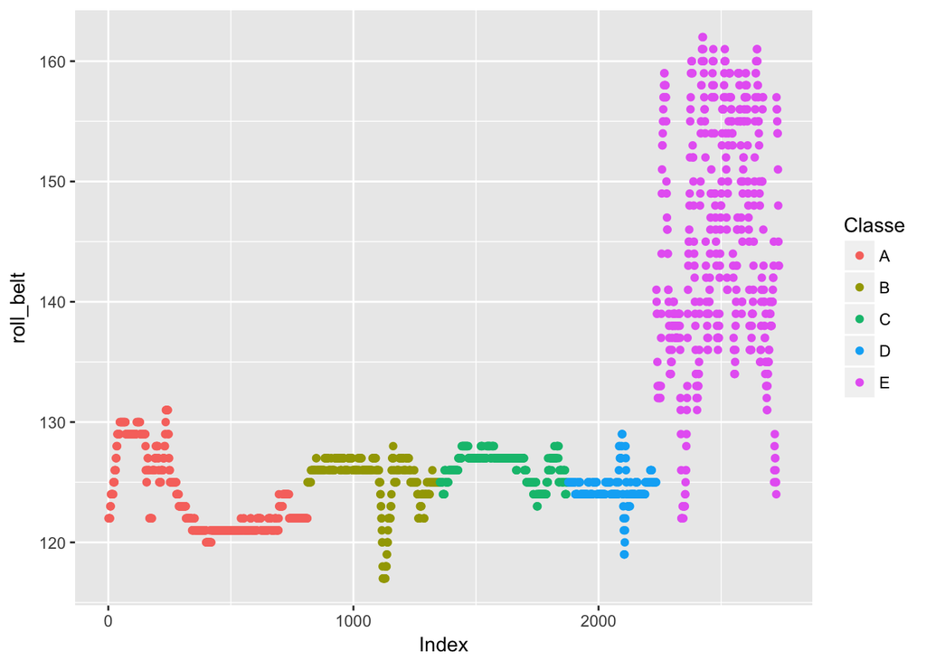

```r
#Plots of the measurements in the training dataset against the class for one participant.
#Showing only first plot to keep the size of the file in limit
plots[1]
```